# Data Exploratory

#### Data exploration on NBA dataset

```r
library(tidyverse)
library(DataExplorer)
```

#### Load data

```r
ranking = read.csv("/Users/georgegasparis/GitHub/GraphBasketAnalysis/Data/ranking.csv")
teams = read.csv("/Users/georgegasparis/GitHub/GraphBasketAnalysis/Data/teams.csv")
players = read.csv("/Users/georgegasparis/GitHub/GraphBasketAnalysis/Data/players.csv")
games = read.csv("/Users/georgegasparis/GitHub/GraphBasketAnalysis/Data/games.csv")
games_details = read.csv("/Users/georgegasparis/GitHub/GraphBasketAnalysis/Data/games_details.csv")
```

### Data overview

The dataframes we’ll use are games_details, games, teams, players and ranking

### games_details

The most complete dataset from the five which game stats for each game and player.

```r
head(games_details,10)
```

|  | GAME_ID | TEAM_ID | TEAM_ABBREVIATION | TEAM_CITY | PLAYER_ID | PLAYER_NAME | START_POSITION | COMMENT | MIN | FGM | FGA | FG_PCT | FG3M | FG3A | FG3_PCT | FTM | FTA | FT_PCT | OREB | DREB | REB | AST | STL | BLK | TO | PF | PTS | PLUS_MINUS |
| --- | --- | --- | --- | --- | --- | --- | --- | --- | --- | --- | --- | --- | --- | --- | --- | --- | --- | --- | --- | --- | --- | --- | --- | --- | --- | --- | --- | --- |
| 1 | 21900895 | 1610612749 | MIL | Milwaukee | 202083 | Wesley Matthews | F |  | 27:08 | 3 | 11 | 0.273 | 2 | 7 | 0.286 | 0 | 0 | 0.000 | 4 | 4 | 8 | 2 | 2 | 0 | 0 | 0 | 8 | 11 |
| 2 | 21900895 | 1610612749 | MIL | Milwaukee | 203507 | Giannis Antetokounmpo | F |  | 34:55 | 17 | 28 | 0.607 | 1 | 4 | 0.250 | 6 | 7 | 0.857 | 2 | 18 | 20 | 6 | 1 | 0 | 3 | 2 | 41 | 22 |
| 3 | 21900895 | 1610612749 | MIL | Milwaukee | 201572 | Brook Lopez | C |  | 26:25 | 4 | 11 | 0.364 | 1 | 5 | 0.200 | 7 | 9 | 0.778 | 2 | 5 | 7 | 0 | 0 | 3 | 0 | 2 | 16 | 16 |
| 4 | 21900895 | 1610612749 | MIL | Milwaukee | 1628978 | Donte DiVincenzo | G |  | 27:35 | 1 | 5 | 0.200 | 0 | 3 | 0.000 | 0 | 0 | 0.000 | 1 | 6 | 7 | 5 | 0 | 1 | 2 | 0 | 2 | 14 |
| 5 | 21900895 | 1610612749 | MIL | Milwaukee | 202339 | Eric Bledsoe | G |  | 22:17 | 2 | 8 | 0.250 | 0 | 1 | 0.000 | 0 | 0 | 0.000 | 1 | 0 | 1 | 2 | 1 | 0 | 3 | 2 | 4 | 6 |
| 6 | 21900895 | 1610612749 | MIL | Milwaukee | 1626192 | Pat Connaughton |  |  | 24:52 | 2 | 5 | 0.400 | 1 | 4 | 0.250 | 1 | 2 | 0.500 | 2 | 3 | 5 | 1 | 0 | 0 | 1 | 2 | 6 | 0 |
| 7 | 21900895 | 1610612749 | MIL | Milwaukee | 201577 | Robin Lopez |  |  | 13:18 | 1 | 5 | 0.200 | 0 | 0 | 0.000 | 0 | 0 | 0.000 | 1 | 2 | 3 | 0 | 0 | 1 | 2 | 1 | 2 | -12 |
| 8 | 21900895 | 1610612749 | MIL | Milwaukee | 1628425 | Sterling Brown |  |  | 18:10 | 1 | 2 | 0.500 | 1 | 2 | 0.500 | 0 | 0 | 0.000 | 0 | 3 | 3 | 0 | 0 | 0 | 1 | 0 | 3 | -8 |
| 9 | 21900895 | 1610612749 | MIL | Milwaukee | 101107 | Marvin Williams |  |  | 19:37 | 0 | 1 | 0.000 | 0 | 1 | 0.000 | 0 | 0 | 0.000 | 0 | 2 | 2 | 2 | 1 | 1 | 1 | 1 | 0 | -11 |
| 10 | 21900895 | 1610612749 | MIL | Milwaukee | 201588 | George Hill |  |  | 25:43 | 4 | 11 | 0.364 | 1 | 4 | 0.250 | 2 | 3 | 0.667 | 2 | 3 | 5 | 2 | 2 | 0 | 3 | 1 | 11 | 2 |

#### Dimensions

The functions `dim` displays the dimension of the table and function `glimpse`, from `dplyr` package, displays a vertical preview of the dataset.

```r
dim(games_details)
```

```
## [1] 576782     28
```

```r
glimpse(games_details)
```

```
## Rows: 576,782
## Columns: 28
## $ GAME_ID           <int> 21900895, 21900895, 21900895, 21900895, 21900895, 2…
## $ TEAM_ID           <int> 1610612749, 1610612749, 1610612749, 1610612749, 161…
## $ TEAM_ABBREVIATION <chr> "MIL", "MIL", "MIL", "MIL", "MIL", "MIL", "MIL", "M…
## $ TEAM_CITY         <chr> "Milwaukee", "Milwaukee", "Milwaukee", "Milwaukee",…
## $ PLAYER_ID         <int> 202083, 203507, 201572, 1628978, 202339, 1626192, 2…
## $ PLAYER_NAME       <chr> "Wesley Matthews", "Giannis Antetokounmpo", "Brook …
## $ START_POSITION    <chr> "F", "F", "C", "G", "G", "", "", "", "", "", "", ""…
## $ COMMENT           <chr> "", "", "", "", "", "", "", "", "", "", "DNP - Coac…
## $ MIN               <chr> "27:08", "34:55", "26:25", "27:35", "22:17", "24:52…
## $ FGM               <dbl> 3, 17, 4, 1, 2, 2, 1, 1, 0, 4, NA, NA, NA, 3, 5, 2,…
## $ FGA               <dbl> 11, 28, 11, 5, 8, 5, 5, 2, 1, 11, NA, NA, NA, 13, 1…
## $ FG_PCT            <dbl> 0.273, 0.607, 0.364, 0.200, 0.250, 0.400, 0.200, 0.…
## $ FG3M              <dbl> 2, 1, 1, 0, 0, 1, 0, 1, 0, 1, NA, NA, NA, 1, 1, 0, …
## $ FG3A              <dbl> 7, 4, 5, 3, 1, 4, 0, 2, 1, 4, NA, NA, NA, 7, 8, 0, …
## $ FG3_PCT           <dbl> 0.286, 0.250, 0.200, 0.000, 0.000, 0.250, 0.000, 0.…
## $ FTM               <dbl> 0, 6, 7, 0, 0, 1, 0, 0, 0, 2, NA, NA, NA, 0, 1, 4, …
## $ FTA               <dbl> 0, 7, 9, 0, 0, 2, 0, 0, 0, 3, NA, NA, NA, 0, 1, 4, …
## $ FT_PCT            <dbl> 0.000, 0.857, 0.778, 0.000, 0.000, 0.500, 0.000, 0.…
## $ OREB              <dbl> 4, 2, 2, 1, 1, 2, 1, 0, 0, 2, NA, NA, NA, 1, 1, 4, …
## $ DREB              <dbl> 4, 18, 5, 6, 0, 3, 2, 3, 2, 3, NA, NA, NA, 3, 5, 5,…
## $ REB               <dbl> 8, 20, 7, 7, 1, 5, 3, 3, 2, 5, NA, NA, NA, 4, 6, 9,…
## $ AST               <dbl> 2, 6, 0, 5, 2, 1, 0, 0, 2, 2, NA, NA, NA, 2, 3, 2, …
## $ STL               <dbl> 2, 1, 0, 0, 1, 0, 0, 0, 1, 2, NA, NA, NA, 2, 0, 0, …
## $ BLK               <dbl> 0, 0, 3, 1, 0, 0, 1, 0, 1, 0, NA, NA, NA, 2, 2, 2, …
## $ TO                <dbl> 0, 3, 0, 2, 3, 1, 2, 1, 1, 3, NA, NA, NA, 2, 2, 1, …
## $ PF                <dbl> 0, 2, 2, 0, 2, 2, 1, 0, 1, 1, NA, NA, NA, 2, 3, 3, …
## $ PTS               <dbl> 8, 41, 16, 2, 4, 6, 2, 3, 0, 11, NA, NA, NA, 7, 12,…
## $ PLUS_MINUS        <dbl> 11, 22, 16, 14, 6, 0, -12, -8, -11, 2, NA, NA, NA, …
```

#### Values in detail

The mean and min-max values of the quantile variables

```r
games_stats <- games_details[c(10,11,13,14,16,17,19,21,22,23,24,25,26,27,28)]
summary(games_stats)
```

```
##       FGM             FGA             FG3M            FG3A
##  Min.   : 0.00   Min.   : 0.00   Min.   : 0.00   Min.   : 0.00
##  1st Qu.: 1.00   1st Qu.: 3.00   1st Qu.: 0.00   1st Qu.: 0.00
##  Median : 3.00   Median : 7.00   Median : 0.00   Median : 1.00
##  Mean   : 3.56   Mean   : 7.86   Mean   : 0.72   Mean   : 2.02
##  3rd Qu.: 5.00   3rd Qu.:11.00   3rd Qu.: 1.00   3rd Qu.: 3.00
##  Max.   :28.00   Max.   :50.00   Max.   :14.00   Max.   :24.00
##  NA's   :92261   NA's   :92261   NA's   :92261   NA's   :92261
##       FTM             FTA             OREB            REB
##  Min.   : 0.00   Min.   : 0.00   Min.   : 0.00   Min.   : 0.00
##  1st Qu.: 0.00   1st Qu.: 0.00   1st Qu.: 0.00   1st Qu.: 1.00
##  Median : 1.00   Median : 2.00   Median : 1.00   Median : 3.00
##  Mean   : 1.75   Mean   : 2.32   Mean   : 1.04   Mean   : 4.05
##  3rd Qu.: 3.00   3rd Qu.: 4.00   3rd Qu.: 2.00   3rd Qu.: 6.00
##  Max.   :26.00   Max.   :39.00   Max.   :18.00   Max.   :31.00
##  NA's   :92261   NA's   :92261   NA's   :92261   NA's   :92261
##       AST             STL             BLK              TO
##  Min.   : 0.00   Min.   : 0.00   Min.   : 0.00   Min.   : 0.00
##  1st Qu.: 0.00   1st Qu.: 0.00   1st Qu.: 0.00   1st Qu.: 0.00
##  Median : 1.00   Median : 0.00   Median : 0.00   Median : 1.00
##  Mean   : 2.08   Mean   : 0.72   Mean   : 0.46   Mean   : 1.33
##  3rd Qu.: 3.00   3rd Qu.: 1.00   3rd Qu.: 1.00   3rd Qu.: 2.00
##  Max.   :25.00   Max.   :10.00   Max.   :12.00   Max.   :12.00
##  NA's   :92261   NA's   :92261   NA's   :92261   NA's   :92261
##        PF             PTS          PLUS_MINUS
##  Min.   : 0.00   Min.   : 0.0    Min.   :-57
##  1st Qu.: 1.00   1st Qu.: 3.0    1st Qu.: -7
##  Median : 2.00   Median : 8.0    Median :  0
##  Mean   : 2.02   Mean   : 9.6    Mean   :  0
##  3rd Qu.: 3.00   3rd Qu.:14.0    3rd Qu.:  6
##  Max.   :15.00   Max.   :81.0    Max.   : 57
##  NA's   :92261   NA's   :92261   NA's   :115922
```

`Skim` function from `skimr` package displays the same variable but also missing values, more quantile information and an inline histogram for each variable.

```r
library(skimr)
skim(games_details)
```

Data summary

| Name | games_details |
| --- | --- |
| Number of rows | 576782 |
| Number of columns | 28 |
| _______________________ |  |
| Column type frequency: |  |
| character | 6 |
| numeric | 22 |
| ________________________ |  |
| Group variables | None |

**Variable type: character**

| skim_variable | n_missing | complete_rate | min | max | empty | n_unique | whitespace |
| --- | --- | --- | --- | --- | --- | --- | --- |
| TEAM_ABBREVIATION | 0 | 1 | 3 | 3 | 0 | 34 | 0 |
| TEAM_CITY | 0 | 1 | 2 | 25 | 0 | 33 | 0 |
| PLAYER_NAME | 0 | 1 | 4 | 24 | 0 | 2294 | 0 |
| START_POSITION | 0 | 1 | 0 | 1 | 355408 | 4 | 0 |
| COMMENT | 0 | 1 | 0 | 40 | 484522 | 5330 | 0 |
| MIN | 0 | 1 | 0 | 5 | 92261 | 3383 | 0 |

**Variable type: numeric**

| skim_variable | n_missing | complete_rate | mean | sd | p0 | p25 | p50 | p75 | p100 | hist |
| --- | --- | --- | --- | --- | --- | --- | --- | --- | --- | --- |
| GAME_ID | 0 | 1.00 | 2.153582e+07 | 5496051.27 | 10300001 | 20600629.00 | 2.110046e+07 | 2.160020e+07 | 41800406 | ▁▇▁▁▁ |
| TEAM_ID | 0 | 1.00 | 1.610613e+09 | 8.66 | 1610612737 | 1610612744.00 | 1.610613e+09 | 1.610613e+09 | 1610612766 | ▇▇▇▇▇ |
| PLAYER_ID | 0 | 1.00 | 2.793802e+05 | 7768096.29 | 15 | 2366.00 | 2.007570e+05 | 2.026930e+05 | 1962937827 | ▇▁▁▁▁ |
| FGM | 92261 | 0.84 | 3.560000e+00 | 3.01 | 0 | 1.00 | 3.000000e+00 | 5.000000e+00 | 28 | ▇▂▁▁▁ |
| FGA | 92261 | 0.84 | 7.860000e+00 | 5.64 | 0 | 3.00 | 7.000000e+00 | 1.100000e+01 | 50 | ▇▃▁▁▁ |
| FG_PCT | 92261 | 0.84 | 4.200000e-01 | 0.25 | 0 | 0.25 | 4.300000e-01 | 5.600000e-01 | 1 | ▅▆▇▃▁ |
| FG3M | 92261 | 0.84 | 7.200000e-01 | 1.18 | 0 | 0.00 | 0.000000e+00 | 1.000000e+00 | 14 | ▇▁▁▁▁ |
| FG3A | 92261 | 0.84 | 2.020000e+00 | 2.46 | 0 | 0.00 | 1.000000e+00 | 3.000000e+00 | 24 | ▇▂▁▁▁ |
| FG3_PCT | 92261 | 0.84 | 1.900000e-01 | 0.29 | 0 | 0.00 | 0.000000e+00 | 3.300000e-01 | 1 | ▇▂▂▁▁ |
| FTM | 92261 | 0.84 | 1.750000e+00 | 2.37 | 0 | 0.00 | 1.000000e+00 | 3.000000e+00 | 26 | ▇▁▁▁▁ |
| FTA | 92261 | 0.84 | 2.320000e+00 | 2.91 | 0 | 0.00 | 2.000000e+00 | 4.000000e+00 | 39 | ▇▁▁▁▁ |
| FT_PCT | 92261 | 0.84 | 4.400000e-01 | 0.43 | 0 | 0.00 | 5.000000e-01 | 9.100000e-01 | 1 | ▇▁▂▂▅ |
| OREB | 92261 | 0.84 | 1.040000e+00 | 1.41 | 0 | 0.00 | 1.000000e+00 | 2.000000e+00 | 18 | ▇▁▁▁▁ |
| DREB | 92261 | 0.84 | 3.010000e+00 | 2.68 | 0 | 1.00 | 2.000000e+00 | 4.000000e+00 | 25 | ▇▂▁▁▁ |
| REB | 92261 | 0.84 | 4.050000e+00 | 3.49 | 0 | 1.00 | 3.000000e+00 | 6.000000e+00 | 31 | ▇▂▁▁▁ |
| AST | 92261 | 0.84 | 2.080000e+00 | 2.46 | 0 | 0.00 | 1.000000e+00 | 3.000000e+00 | 25 | ▇▁▁▁▁ |
| STL | 92261 | 0.84 | 7.200000e-01 | 0.98 | 0 | 0.00 | 0.000000e+00 | 1.000000e+00 | 10 | ▇▁▁▁▁ |
| BLK | 92261 | 0.84 | 4.600000e-01 | 0.87 | 0 | 0.00 | 0.000000e+00 | 1.000000e+00 | 12 | ▇▁▁▁▁ |
| TO | 92261 | 0.84 | 1.330000e+00 | 1.40 | 0 | 0.00 | 1.000000e+00 | 2.000000e+00 | 12 | ▇▂▁▁▁ |
| PF | 92261 | 0.84 | 2.020000e+00 | 1.51 | 0 | 1.00 | 2.000000e+00 | 3.000000e+00 | 15 | ▇▂▁▁▁ |
| PTS | 92261 | 0.84 | 9.600000e+00 | 8.00 | 0 | 3.00 | 8.000000e+00 | 1.400000e+01 | 81 | ▇▂▁▁▁ |
| PLUS_MINUS | 115922 | 0.80 | 0.000000e+00 | 10.55 | -57 | -7.00 | 0.000000e+00 | 6.000000e+00 | 57 | ▁▂▇▂▁ |

Metrics on data overall using funtion `plot_intro`.

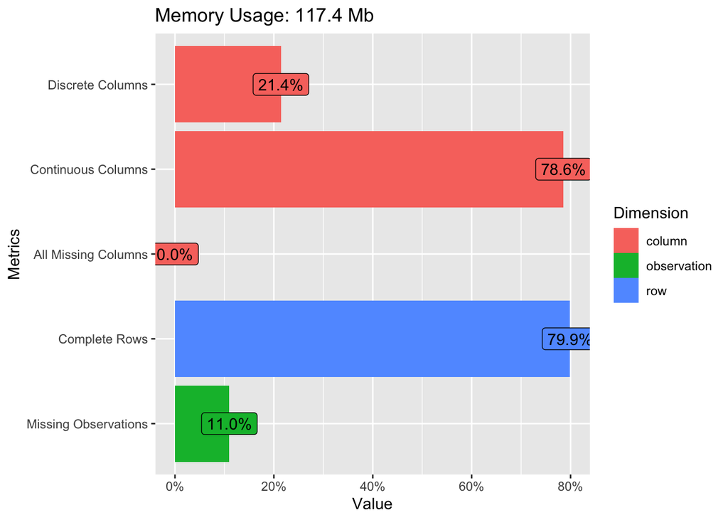

```r
plot_intro(games_details)
```

#### Missing values Check for missing values using function `plot_missing`. We see that there isn’t a variable with such missing values that needs to be removed. In that case we should use the `drop_columns` function.

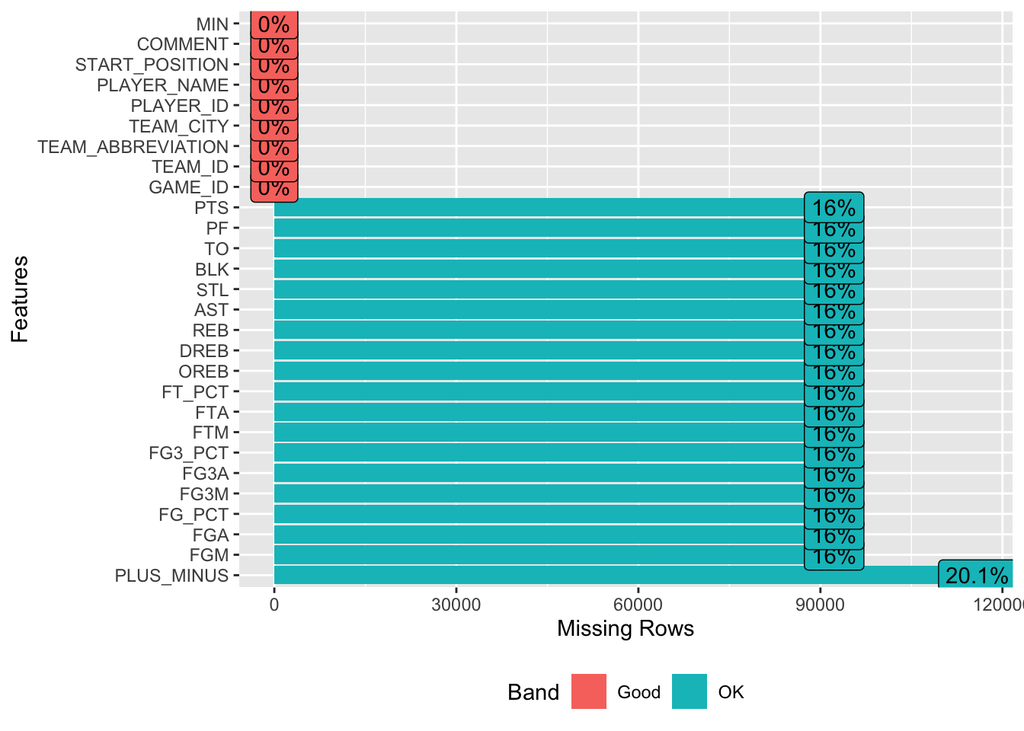

```r
plot_missing(games_details)
```

### games

```r
head(games,10)
```

|  | GAME_DATE_EST | GAME_ID | GAME_STATUS_TEXT | HOME_TEAM_ID | VISITOR_TEAM_ID | SEASON | TEAM_ID_home | PTS_home | FG_PCT_home | FT_PCT_home | FG3_PCT_home | AST_home | REB_home | TEAM_ID_away | PTS_away | FG_PCT_away | FT_PCT_away | FG3_PCT_away | AST_away | REB_away | HOME_TEAM_WINS |
| --- | --- | --- | --- | --- | --- | --- | --- | --- | --- | --- | --- | --- | --- | --- | --- | --- | --- | --- | --- | --- | --- |
| 1 | 2020-03-01 | 21900895 | Final | 1610612766 | 1610612749 | 2019 | 1610612766 | 85 | 0.354 | 0.900 | 0.229 | 22 | 47 | 1610612749 | 93 | 0.402 | 0.762 | 0.226 | 20 | 61 | 0 |
| 2 | 2020-03-01 | 21900896 | Final | 1610612750 | 1610612742 | 2019 | 1610612750 | 91 | 0.364 | 0.400 | 0.310 | 19 | 57 | 1610612742 | 111 | 0.468 | 0.632 | 0.275 | 28 | 56 | 0 |
| 3 | 2020-03-01 | 21900897 | Final | 1610612746 | 1610612755 | 2019 | 1610612746 | 136 | 0.592 | 0.805 | 0.542 | 25 | 37 | 1610612755 | 130 | 0.505 | 0.650 | 0.488 | 27 | 37 | 1 |
| 4 | 2020-03-01 | 21900898 | Final | 1610612743 | 1610612761 | 2019 | 1610612743 | 133 | 0.566 | 0.700 | 0.500 | 38 | 41 | 1610612761 | 118 | 0.461 | 0.897 | 0.263 | 24 | 36 | 1 |
| 5 | 2020-03-01 | 21900899 | Final | 1610612758 | 1610612765 | 2019 | 1610612758 | 106 | 0.407 | 0.885 | 0.257 | 18 | 51 | 1610612765 | 100 | 0.413 | 0.667 | 0.429 | 23 | 42 | 1 |
| 6 | 2020-03-01 | 21900900 | Final | 1610612740 | 1610612747 | 2019 | 1610612740 | 114 | 0.421 | 0.818 | 0.219 | 24 | 52 | 1610612747 | 122 | 0.515 | 0.900 | 0.371 | 23 | 36 | 0 |
| 7 | 2020-03-01 | 21900901 | Final | 1610612744 | 1610612764 | 2019 | 1610612744 | 110 | 0.472 | 0.708 | 0.321 | 25 | 52 | 1610612764 | 124 | 0.488 | 0.889 | 0.667 | 24 | 34 | 0 |
| 8 | 2020-02-29 | 21900887 | Final | 1610612752 | 1610612741 | 2019 | 1610612752 | 125 | 0.553 | 0.697 | 0.400 | 29 | 50 | 1610612741 | 115 | 0.461 | 0.696 | 0.486 | 26 | 33 | 1 |
| 9 | 2020-02-29 | 21900888 | Final | 1610612737 | 1610612757 | 2019 | 1610612737 | 129 | 0.548 | 0.864 | 0.429 | 34 | 36 | 1610612757 | 117 | 0.500 | 0.714 | 0.286 | 14 | 42 | 1 |
| 10 | 2020-02-29 | 21900889 | Final | 1610612748 | 1610612751 | 2019 | 1610612748 | 116 | 0.451 | 0.833 | 0.368 | 27 | 45 | 1610612751 | 113 | 0.465 | 0.739 | 0.364 | 30 | 44 | 1 |

#### Dimensions and columns

```r
dim(games)
```

```
## [1] 23195    21
```

```r
glimpse(games)
```

```
## Rows: 23,195
## Columns: 21
## $ GAME_DATE_EST    <chr> "2020-03-01", "2020-03-01", "2020-03-01", "2020-03-0…
## $ GAME_ID          <int> 21900895, 21900896, 21900897, 21900898, 21900899, 21…
## $ GAME_STATUS_TEXT <chr> "Final", "Final", "Final", "Final", "Final", "Final"…
## $ HOME_TEAM_ID     <int> 1610612766, 1610612750, 1610612746, 1610612743, 1610…
## $ VISITOR_TEAM_ID  <int> 1610612749, 1610612742, 1610612755, 1610612761, 1610…
## $ SEASON           <int> 2019, 2019, 2019, 2019, 2019, 2019, 2019, 2019, 2019…
## $ TEAM_ID_home     <int> 1610612766, 1610612750, 1610612746, 1610612743, 1610…
## $ PTS_home         <dbl> 85, 91, 136, 133, 106, 114, 110, 125, 129, 116, 104,…
## $ FG_PCT_home      <dbl> 0.354, 0.364, 0.592, 0.566, 0.407, 0.421, 0.472, 0.5…
## $ FT_PCT_home      <dbl> 0.900, 0.400, 0.805, 0.700, 0.885, 0.818, 0.708, 0.6…
## $ FG3_PCT_home     <dbl> 0.229, 0.310, 0.542, 0.500, 0.257, 0.219, 0.321, 0.4…
## $ AST_home         <dbl> 22, 19, 25, 38, 18, 24, 25, 29, 34, 27, 30, 27, 22, …
## $ REB_home         <dbl> 47, 57, 37, 41, 51, 52, 52, 50, 36, 45, 36, 51, 54, …
## $ TEAM_ID_away     <int> 1610612749, 1610612742, 1610612755, 1610612761, 1610…
## $ PTS_away         <dbl> 93, 111, 130, 118, 100, 122, 124, 115, 117, 113, 113…
## $ FG_PCT_away      <dbl> 0.402, 0.468, 0.505, 0.461, 0.413, 0.515, 0.488, 0.4…
## $ FT_PCT_away      <dbl> 0.762, 0.632, 0.650, 0.897, 0.667, 0.900, 0.889, 0.6…
## $ FG3_PCT_away     <dbl> 0.226, 0.275, 0.488, 0.263, 0.429, 0.371, 0.667, 0.4…
## $ AST_away         <dbl> 20, 28, 27, 24, 23, 23, 24, 26, 14, 30, 30, 26, 17, …
## $ REB_away         <dbl> 61, 56, 37, 36, 42, 36, 34, 33, 42, 44, 38, 45, 53, …
## $ HOME_TEAM_WINS   <int> 0, 0, 1, 1, 1, 0, 0, 1, 1, 1, 0, 1, 0, 1, 0, 1, 1, 0…
```

#### Values in detail

Analysis of quantile values

```r
games_pts <- games[c(8,9,10,12,13,15,16,17,18,19)]
summary(games_pts)
```

```
##     PTS_home      FG_PCT_home      FT_PCT_home        AST_home
##  Min.   : 36.0   Min.   :0.2500   Min.   :0.1430   Min.   : 6.00
##  1st Qu.: 93.0   1st Qu.:0.4200   1st Qu.:0.6960   1st Qu.:19.00
##  Median :102.0   Median :0.4590   Median :0.7650   Median :22.00
##  Mean   :102.1   Mean   :0.4599   Mean   :0.7579   Mean   :22.51
##  3rd Qu.:111.0   3rd Qu.:0.5000   3rd Qu.:0.8260   3rd Qu.:26.00
##  Max.   :168.0   Max.   :0.6840   Max.   :1.0000   Max.   :47.00
##  NA's   :99      NA's   :99       NA's   :99       NA's   :99
##     REB_home        PTS_away       FG_PCT_away      FT_PCT_away
##  Min.   :15.00   Min.   : 33.00   Min.   :0.2440   Min.   :0.1430
##  1st Qu.:39.00   1st Qu.: 90.00   1st Qu.:0.4100   1st Qu.:0.6920
##  Median :43.00   Median : 99.00   Median :0.4470   Median :0.7620
##  Mean   :43.17   Mean   : 99.17   Mean   :0.4481   Mean   :0.7562
##  3rd Qu.:48.00   3rd Qu.:108.00   3rd Qu.:0.4860   3rd Qu.:0.8280
##  Max.   :72.00   Max.   :168.00   Max.   :0.6740   Max.   :1.0000
##  NA's   :99      NA's   :99       NA's   :99       NA's   :99
##   FG3_PCT_away       AST_away
##  Min.   :0.0000   Min.   : 4.0
##  1st Qu.:0.2730   1st Qu.:18.0
##  Median :0.3480   Median :21.0
##  Mean   :0.3487   Mean   :21.1
##  3rd Qu.:0.4210   3rd Qu.:24.0
##  Max.   :1.0000   Max.   :46.0
##  NA's   :99       NA's   :99
```

```r
skim(games_pts)
```

Data summary

| Name | games_pts |
| --- | --- |
| Number of rows | 23195 |
| Number of columns | 10 |
| _______________________ |  |
| Column type frequency: |  |
| numeric | 10 |
| ________________________ |  |
| Group variables | None |

**Variable type: numeric**

| skim_variable | n_missing | complete_rate | mean | sd | p0 | p25 | p50 | p75 | p100 | hist |
| --- | --- | --- | --- | --- | --- | --- | --- | --- | --- | --- |
| PTS_home | 99 | 1 | 102.15 | 12.90 | 36.00 | 93.00 | 102.00 | 111.00 | 168.00 | ▁▂▇▂▁ |
| FG_PCT_home | 99 | 1 | 0.46 | 0.06 | 0.25 | 0.42 | 0.46 | 0.50 | 0.68 | ▁▃▇▃▁ |
| FT_PCT_home | 99 | 1 | 0.76 | 0.10 | 0.14 | 0.70 | 0.76 | 0.83 | 1.00 | ▁▁▂▇▃ |
| AST_home | 99 | 1 | 22.51 | 5.15 | 6.00 | 19.00 | 22.00 | 26.00 | 47.00 | ▁▇▇▁▁ |
| REB_home | 99 | 1 | 43.17 | 6.60 | 15.00 | 39.00 | 43.00 | 48.00 | 72.00 | ▁▂▇▂▁ |
| PTS_away | 99 | 1 | 99.17 | 12.95 | 33.00 | 90.00 | 99.00 | 108.00 | 168.00 | ▁▂▇▂▁ |
| FG_PCT_away | 99 | 1 | 0.45 | 0.06 | 0.24 | 0.41 | 0.45 | 0.49 | 0.67 | ▁▃▇▂▁ |
| FT_PCT_away | 99 | 1 | 0.76 | 0.10 | 0.14 | 0.69 | 0.76 | 0.83 | 1.00 | ▁▁▂▇▃ |
| FG3_PCT_away | 99 | 1 | 0.35 | 0.11 | 0.00 | 0.27 | 0.35 | 0.42 | 1.00 | ▁▇▃▁▁ |
| AST_away | 99 | 1 | 21.10 | 5.08 | 4.00 | 18.00 | 21.00 | 24.00 | 46.00 | ▁▇▇▁▁ |

Metrics on data overall using funtion `plot_intro`.

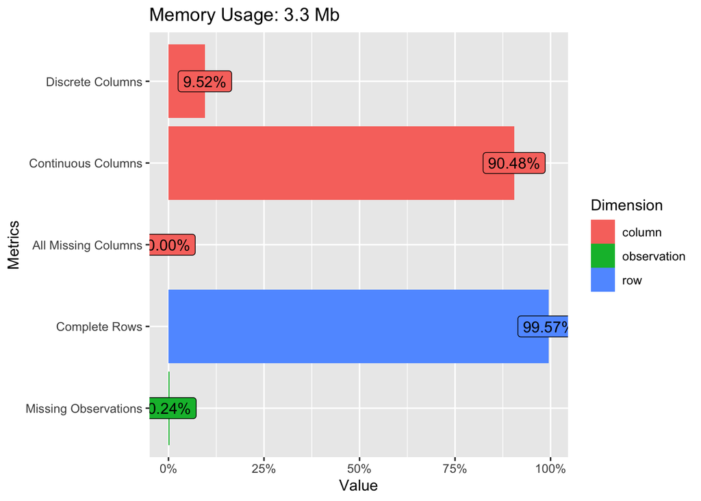

```r
plot_intro(games)
```

#### Missing values Check for missing values using function `plot_missing`. We see that there isn’t a variable with such missing values that needs to be removed. In that case we should use the `drop_columns` function.

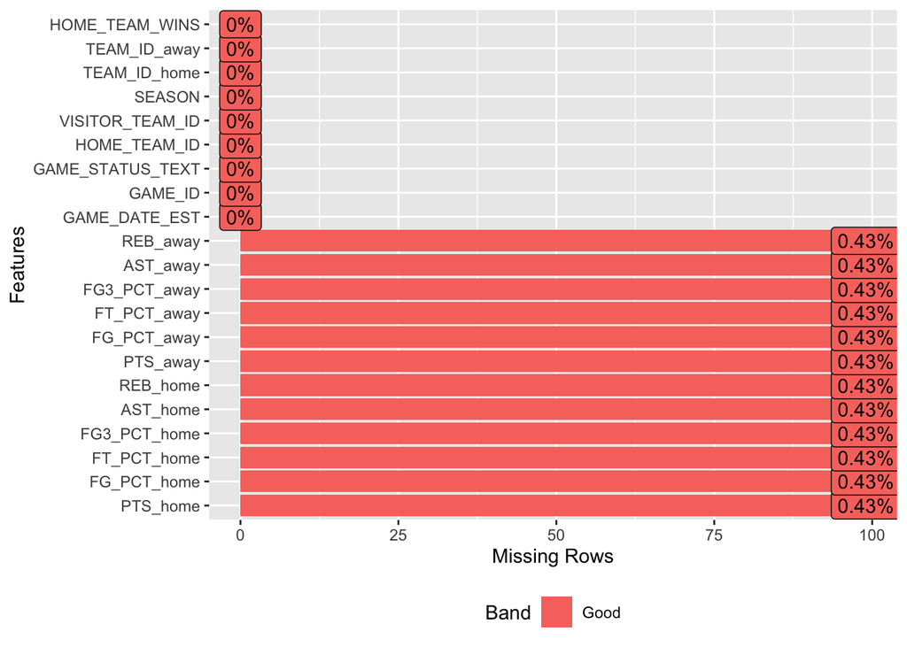

```r
plot_missing(games)
```

### ranking

```r
head(ranking,10)
```

|  | TEAM_ID | LEAGUE_ID | SEASON_ID | STANDINGSDATE | CONFERENCE | TEAM | G | W | L | W_PCT | HOME_RECORD | ROAD_RECORD |
| --- | --- | --- | --- | --- | --- | --- | --- | --- | --- | --- | --- | --- |
| 1 | 1610612747 | 0 | 22019 | 2020-03-01 | West | L.A. Lakers | 59 | 46 | 13 | 0.780 | 21-7 | 25-6 |
| 2 | 1610612743 | 0 | 22019 | 2020-03-01 | West | Denver | 60 | 41 | 19 | 0.683 | 24-7 | 17-12 |
| 3 | 1610612746 | 0 | 22019 | 2020-03-01 | West | LA Clippers | 60 | 41 | 19 | 0.683 | 25-6 | 16-13 |
| 4 | 1610612745 | 0 | 22019 | 2020-03-01 | West | Houston | 59 | 39 | 20 | 0.661 | 21-8 | 18-12 |
| 5 | 1610612762 | 0 | 22019 | 2020-03-01 | West | Utah | 59 | 37 | 22 | 0.627 | 21-9 | 16-13 |
| 6 | 1610612760 | 0 | 22019 | 2020-03-01 | West | Oklahoma City | 60 | 37 | 23 | 0.617 | 20-12 | 17-11 |
| 7 | 1610612742 | 0 | 22019 | 2020-03-01 | West | Dallas | 61 | 37 | 24 | 0.607 | 16-14 | 21-10 |
| 8 | 1610612763 | 0 | 22019 | 2020-03-01 | West | Memphis | 60 | 29 | 31 | 0.483 | 17-14 | 12-17 |
| 9 | 1610612740 | 0 | 22019 | 2020-03-01 | West | New Orleans | 60 | 26 | 34 | 0.433 | 12-18 | 14-16 |
| 10 | 1610612758 | 0 | 22019 | 2020-03-01 | West | Sacramento | 60 | 26 | 34 | 0.433 | 13-15 | 13-19 |

#### Dimensions & columns

```r
dim(ranking)
```

```
## [1] 179533     12
```

```r
glimpse(ranking)
```

```
## Rows: 179,533
## Columns: 12
## $ TEAM_ID       <int> 1610612747, 1610612743, 1610612746, 1610612745, 1610612…
## $ LEAGUE_ID     <int> 0, 0, 0, 0, 0, 0, 0, 0, 0, 0, 0, 0, 0, 0, 0, 0, 0, 0, 0…
## $ SEASON_ID     <int> 22019, 22019, 22019, 22019, 22019, 22019, 22019, 22019,…
## $ STANDINGSDATE <chr> "2020-03-01", "2020-03-01", "2020-03-01", "2020-03-01",…
## $ CONFERENCE    <chr> "West", "West", "West", "West", "West", "West", "West",…
## $ TEAM          <chr> "L.A. Lakers", "Denver", "LA Clippers", "Houston", "Uta…
## $ G             <int> 59, 60, 60, 59, 59, 60, 61, 60, 60, 60, 58, 61, 61, 59,…
## $ W             <int> 46, 41, 41, 39, 37, 37, 37, 29, 26, 26, 25, 26, 24, 17,…
## $ L             <int> 13, 19, 19, 20, 22, 23, 24, 31, 34, 34, 33, 35, 37, 42,…
## $ W_PCT         <dbl> 0.780, 0.683, 0.683, 0.661, 0.627, 0.617, 0.607, 0.483,…
## $ HOME_RECORD   <chr> "21-7", "24-7", "25-6", "21-8", "21-9", "20-12", "16-14…
## $ ROAD_RECORD   <chr> "25-6", "17-12", "16-13", "18-12", "16-13", "17-11", "2…
```

#### Values in detail

```r
ranking_val <- ranking[c(7,8,9,10)]
summary(ranking_val)
```

```
##        G               W              L             W_PCT
##  Min.   : 0.00   Min.   : 0.0   Min.   : 0.00   Min.   :0.0000
##  1st Qu.:32.00   1st Qu.:14.0   1st Qu.:14.00   1st Qu.:0.3710
##  Median :70.00   Median :29.0   Median :29.00   Median :0.5000
##  Mean   :56.99   Mean   :28.5   Mean   :28.49   Mean   :0.4926
##  3rd Qu.:82.00   3rd Qu.:42.0   3rd Qu.:41.00   3rd Qu.:0.6210
##  Max.   :82.00   Max.   :73.0   Max.   :72.00   Max.   :1.0000
```

```r
skim(ranking_val)
```

Data summary

| Name | ranking_val |
| --- | --- |
| Number of rows | 179533 |
| Number of columns | 4 |
| _______________________ |  |
| Column type frequency: |  |
| numeric | 4 |
| ________________________ |  |
| Group variables | None |

**Variable type: numeric**

| skim_variable | n_missing | complete_rate | mean | sd | p0 | p25 | p50 | p75 | p100 | hist |
| --- | --- | --- | --- | --- | --- | --- | --- | --- | --- | --- |
| G | 0 | 1 | 56.99 | 29.01 | 0 | 32.00 | 70.0 | 82.00 | 82 | ▂▂▂▂▇ |
| W | 0 | 1 | 28.50 | 17.49 | 0 | 14.00 | 29.0 | 42.00 | 73 | ▇▇▇▆▁ |
| L | 0 | 1 | 28.49 | 17.50 | 0 | 14.00 | 29.0 | 41.00 | 72 | ▇▇▇▅▂ |
| W_PCT | 0 | 1 | 0.49 | 0.19 | 0 | 0.37 | 0.5 | 0.62 | 1 | ▁▅▇▅▁ |

Metrics on data overall using funtion `plot_intro`.

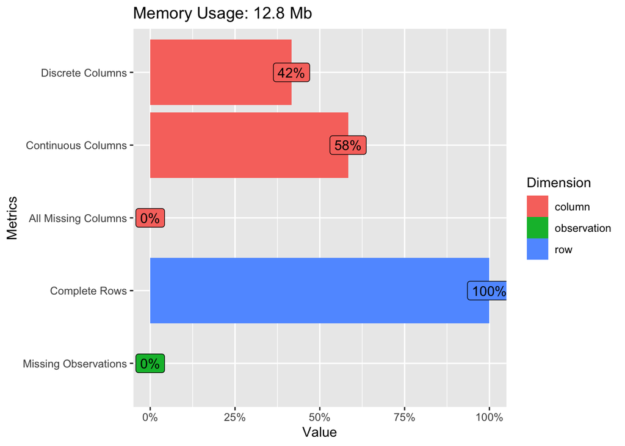

```r
plot_intro(ranking)
```

#### Missing values Check for missing values using function `plot_missing`. We see that there isn’t a variable with such missing values that needs to be removed. In that case we should use the `drop_columns` function.

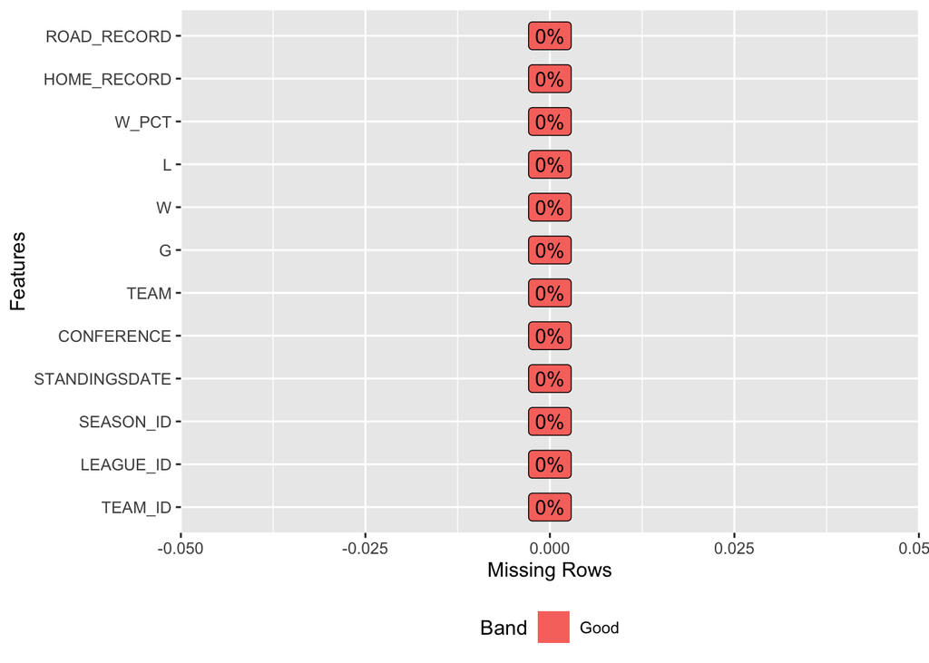

```r
plot_missing(ranking)
```

#### players

```r
head(players,10)
```

|  | PLAYER_NAME | TEAM_ID | PLAYER_ID | SEASON |
| --- | --- | --- | --- | --- |
| 1 | Royce O'Neale | 1610612762 | 1626220 | 2019 |
| 2 | Bojan Bogdanovic | 1610612762 | 202711 | 2019 |
| 3 | Rudy Gobert | 1610612762 | 203497 | 2019 |
| 4 | Donovan Mitchell | 1610612762 | 1628378 | 2019 |
| 5 | Mike Conley | 1610612762 | 201144 | 2019 |
| 6 | Joe Ingles | 1610612762 | 204060 | 2019 |
| 7 | Ed Davis | 1610612762 | 202334 | 2019 |
| 8 | Jeff Green | 1610612762 | 201145 | 2019 |
| 9 | Dante Exum | 1610612762 | 203957 | 2019 |
| 10 | Emmanuel Mudiay | 1610612762 | 1626144 | 2019 |

#### Dimensions

```r
dim(players)
```

```
## [1] 7228    4
```

```r
glimpse(players)
```

```
## Rows: 7,228
## Columns: 4
## $ PLAYER_NAME <chr> "Royce O'Neale", "Bojan Bogdanovic", "Rudy Gobert", "Dono…
## $ TEAM_ID     <int> 1610612762, 1610612762, 1610612762, 1610612762, 161061276…
## $ PLAYER_ID   <int> 1626220, 202711, 203497, 1628378, 201144, 204060, 202334,…
## $ SEASON      <int> 2019, 2019, 2019, 2019, 2019, 2019, 2019, 2019, 2019, 201…
```

```r
skim(players)
```

Data summary

| Name | players |
| --- | --- |
| Number of rows | 7228 |
| Number of columns | 4 |
| _______________________ |  |
| Column type frequency: |  |
| character | 1 |
| numeric | 3 |
| ________________________ |  |
| Group variables | None |

**Variable type: character**

| skim_variable | n_missing | complete_rate | min | max | empty | n_unique | whitespace |
| --- | --- | --- | --- | --- | --- | --- | --- |
| PLAYER_NAME | 0 | 1 | 4 | 24 | 0 | 1749 | 0 |

**Variable type: numeric**

| skim_variable | n_missing | complete_rate | mean | sd | p0 | p25 | p50 | p75 | p100 | hist |
| --- | --- | --- | --- | --- | --- | --- | --- | --- | --- | --- |
| TEAM_ID | 0 | 1 | 1.610613e+09 | 8.72 | 1610612737 | 1610612744 | 1610612751.0 | 1610612759 | 1610612766 | ▇▇▇▇▇ |
| PLAYER_ID | 0 | 1 | 2.355862e+06 | 61066884.73 | 244 | 200768 | 202346.5 | 203910 | 1962937827 | ▇▁▁▁▁ |
| SEASON | 0 | 1 | 2.014160e+03 | 3.13 | 2009 | 2012 | 2014.0 | 2017 | 2019 | ▇▆▆▆▆ |

[figure not shown]

```r
plot_intro(games)
```

[output not shown]

[figure not shown]

```r
plot_missing(games)
```

[output not shown]

#### teams

```r
head(teams,10)
```

|  | LEAGUE_ID | TEAM_ID | MIN_YEAR | MAX_YEAR | ABBREVIATION | NICKNAME | YEARFOUNDED | CITY | ARENA | ARENACAPACITY | OWNER | GENERALMANAGER | HEADCOACH | DLEAGUEAFFILIATION |
| --- | --- | --- | --- | --- | --- | --- | --- | --- | --- | --- | --- | --- | --- | --- |
| 1 | 0 | 1610612737 | 1949 | 2019 | ATL | Hawks | 1949 | Atlanta | State Farm Arena | 18729 | Tony Ressler | Travis Schlenk | Lloyd Pierce | Erie Bayhawks |
| 2 | 0 | 1610612738 | 1946 | 2019 | BOS | Celtics | 1946 | Boston | TD Garden | 18624 | Wyc Grousbeck | Danny Ainge | Brad Stevens | Maine Red Claws |
| 3 | 0 | 1610612740 | 2002 | 2019 | NOP | Pelicans | 2002 | New Orleans | Smoothie King Center | NA | Tom Benson | Trajan Langdon | Alvin Gentry | No Affiliate |
| 4 | 0 | 1610612741 | 1966 | 2019 | CHI | Bulls | 1966 | Chicago | United Center | 21711 | Jerry Reinsdorf | Gar Forman | Jim Boylen | Windy City Bulls |
| 5 | 0 | 1610612742 | 1980 | 2019 | DAL | Mavericks | 1980 | Dallas | American Airlines Center | 19200 | Mark Cuban | Donnie Nelson | Rick Carlisle | Texas Legends |
| 6 | 0 | 1610612743 | 1976 | 2019 | DEN | Nuggets | 1976 | Denver | Pepsi Center | 19099 | Stan Kroenke | Tim Connelly | Michael Malone | No Affiliate |
| 7 | 0 | 1610612745 | 1967 | 2019 | HOU | Rockets | 1967 | Houston | Toyota Center | 18104 | Tilman Fertitta | Daryl Morey | Mike D'Antoni | Rio Grande Valley Vipers |
| 8 | 0 | 1610612746 | 1970 | 2019 | LAC | Clippers | 1970 | Los Angeles | Staples Center | 19060 | Steve Ballmer | Michael Winger | Doc Rivers | Agua Caliente Clippers of Ontario |
| 9 | 0 | 1610612747 | 1948 | 2019 | LAL | Lakers | 1948 | Los Angeles | Staples Center | 19060 | Jerry Buss Family Trust | Rob Pelinka | Frank Vogel | South Bay Lakers |
| 10 | 0 | 1610612748 | 1988 | 2019 | MIA | Heat | 1988 | Miami | AmericanAirlines Arena | 19600 | Micky Arison | Pat Riley | Erik Spoelstra | Sioux Falls Skyforce |

#### Dimensions

```r
dim(teams)
```

```
## [1] 30 14
```

```r
glimpse(teams)
```

```
## Rows: 30
## Columns: 14
## $ LEAGUE_ID          <int> 0, 0, 0, 0, 0, 0, 0, 0, 0, 0, 0, 0, 0, 0, 0, 0, 0,…
## $ TEAM_ID            <int> 1610612737, 1610612738, 1610612740, 1610612741, 16…
## $ MIN_YEAR           <int> 1949, 1946, 2002, 1966, 1980, 1976, 1967, 1970, 19…
## $ MAX_YEAR           <int> 2019, 2019, 2019, 2019, 2019, 2019, 2019, 2019, 20…
## $ ABBREVIATION       <chr> "ATL", "BOS", "NOP", "CHI", "DAL", "DEN", "HOU", "…
## $ NICKNAME           <chr> "Hawks", "Celtics", "Pelicans", "Bulls", "Maverick…
## $ YEARFOUNDED        <int> 1949, 1946, 2002, 1966, 1980, 1976, 1967, 1970, 19…
## $ CITY               <chr> "Atlanta", "Boston", "New Orleans", "Chicago", "Da…
## $ ARENA              <chr> "State Farm Arena", "TD Garden", "Smoothie King Ce…
## $ ARENACAPACITY      <int> 18729, 18624, NA, 21711, 19200, 19099, 18104, 1906…
## $ OWNER              <chr> "Tony Ressler", "Wyc Grousbeck", "Tom Benson", "Je…
## $ GENERALMANAGER     <chr> "Travis Schlenk", "Danny Ainge", "Trajan Langdon",…
## $ HEADCOACH          <chr> "Lloyd Pierce", "Brad Stevens", "Alvin Gentry", "J…
## $ DLEAGUEAFFILIATION <chr> "Erie Bayhawks", "Maine Red Claws", "No Affiliate"…
```

#### Values in detail

```r
teams_stats <- teams[c(3,4,7,10)]
summary(teams_stats)
```

```
##     MIN_YEAR       MAX_YEAR     YEARFOUNDED   ARENACAPACITY
##  Min.   :1946   Min.   :2019   Min.   :1946   Min.   :    0
##  1st Qu.:1952   1st Qu.:2019   1st Qu.:1952   1st Qu.:18642
##  Median :1970   Median :2019   Median :1970   Median :19131
##  Mean   :1970   Mean   :2019   Mean   :1970   Mean   :18553
##  3rd Qu.:1979   3rd Qu.:2019   3rd Qu.:1979   3rd Qu.:19791
##  Max.   :2002   Max.   :2019   Max.   :2002   Max.   :21711
##                                               NA's   :4
```

```r
skim(teams_stats)
```

Data summary

| Name | teams_stats |
| --- | --- |
| Number of rows | 30 |
| Number of columns | 4 |
| _______________________ |  |
| Column type frequency: |  |
| numeric | 4 |
| ________________________ |  |
| Group variables | None |

**Variable type: numeric**

| skim_variable | n_missing | complete_rate | mean | sd | p0 | p25 | p50 | p75 | p100 | hist |
| --- | --- | --- | --- | --- | --- | --- | --- | --- | --- | --- |
| MIN_YEAR | 0 | 1.00 | 1969.70 | 16.70 | 1946 | 1952.0 | 1970 | 1979.00 | 2002 | ▇▆▇▅▃ |
| MAX_YEAR | 0 | 1.00 | 2019.00 | 0.00 | 2019 | 2019.0 | 2019 | 2019.00 | 2019 | ▁▁▇▁▁ |
| YEARFOUNDED | 0 | 1.00 | 1969.70 | 16.70 | 1946 | 1952.0 | 1970 | 1979.00 | 2002 | ▇▆▇▅▃ |
| ARENACAPACITY | 4 | 0.87 | 18553.31 | 3916.92 | 0 | 18641.5 | 19131 | 19790.75 | 21711 | ▁▁▁▁▇ |

Metrics on data overall using funtion `plot_intro`.

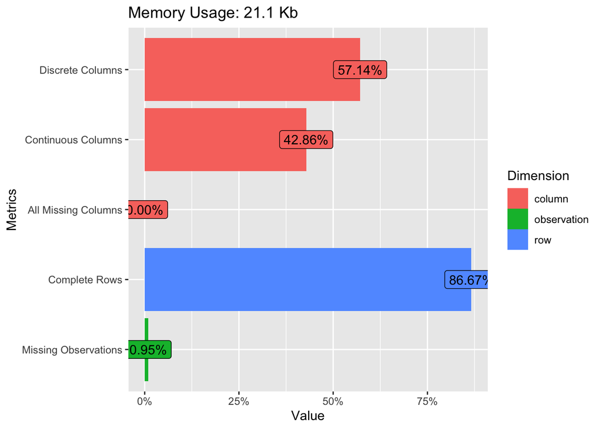

```r
plot_intro(teams)
```

#### Missing values Check for missing values using function `plot_missing`. We see that there isn’t a variable with such missing values that needs to be removed. In that case we should use the `drop_columns` function.

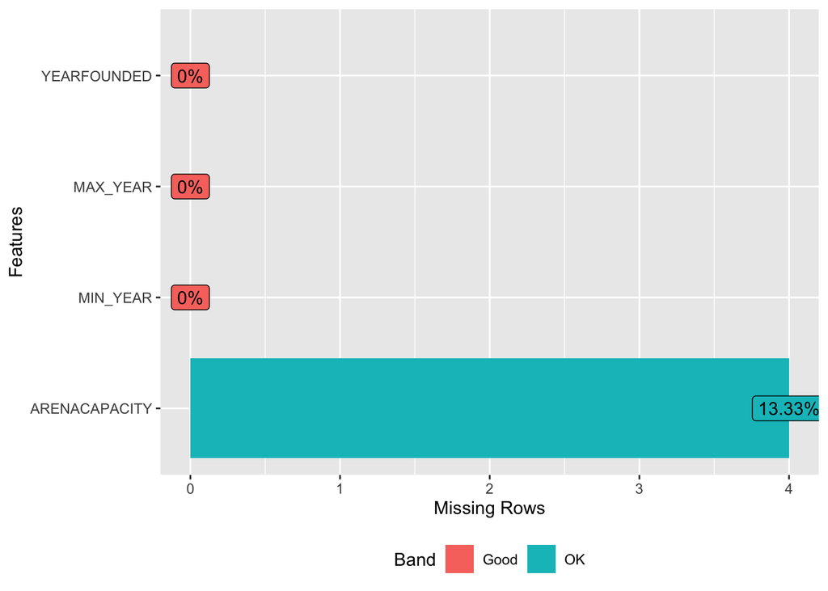

```r
plot_missing(teams_stats)
```